# Student t using correlation coefficient

## Context

The purpose of this post is to show one of the problems of using the p-value as a criterion with large sample sizes (and frequentist statistics more generally). We will see how easy it is to find false positives when testing the significance of a coefficient in linear regression.

We want to show that, for a low level of correlation, it is enough to have a large enough sample size to obtain a significant p-value (which is exactly the same as having a sufficiently high $t$ statistic).

Even if the demonstration is not really important here, the conclusion is important and should be known by all those who use linear regressions.

## Main idea

We can prove that the $t$ statistics of a given coefficient can be write as follow:
$$t = \frac{\hat\beta - 0}{\hat\sigma_{\hat\beta}}
\approx cor(x,y) \times \sqrt{n-k}$$

If we set a Type I error threshold at 5%, it is (more or less) equivalent to rejecting the null hypothesis that $\beta = 0$ if $t>1.96$. The equation above is fairly self-explanatory: whatever the level of correlation, if our sample size is large enough, our test will tell us that the variable associated with $\beta$ has a significant impact on the predicted variable.

Another thing to keep in mind is that a sample size that is too small is also a problem, especially for the error-following law. With frequentist statistics, the sample size really matters and has some important limitations. Always remember that the effect size is not optional in statistics and that the p-value is not a complete result.

One could argue that a larger sample size decreases Type I and Type II errors, and increases the power of the statistic, and this is true. The problem I am talking about is the fact that the effect size needed to detect an effect does not have to be large to be significant.

## Example

In this section, we will create data with a low correlation level and show that we still can find them significantly related.

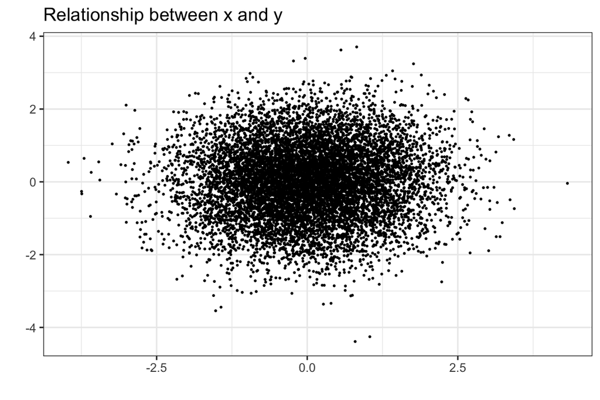

```r
#plot their relationship
library(ggplot2)
library(hrbrthemes)
ggplot(data, aes(x=x, y=y)) +
  geom_point(size=0.3) +
  ggtitle("Relationship between x and y") + xlab("") + ylab("") + theme_bw()
```

As you can see, it is difficult to see anything other than 2 variables with no particular correlation. Let’s check this by using the Pearson correlation coefficient:

```r
cor(x,y)
```

```
## [1] 0.04302613
```

Their correlation is actually not very important. But if we try to predict $y$ with $x$ and have a threshold at $5\%$, we will have a different conclusion:

```r
regression = lm(y ~ x)
summary(regression)
```

```
##
## Call:
## lm(formula = y ~ x)
##
## Residuals:
##     Min      1Q  Median      3Q     Max
## -4.4165 -0.6741  0.0154  0.6732  3.6758
##
## Coefficients:
##              Estimate Std. Error t value Pr(>|t|)
## (Intercept) -0.004566   0.009938  -0.459    0.646
## x            0.042552   0.009882   4.306 1.68e-05 ***
## ---
## Signif. codes:  0 '***' 0.001 '**' 0.01 '*' 0.05 '.' 0.1 ' ' 1
##
## Residual standard error: 0.9938 on 9998 degrees of freedom
## Multiple R-squared:  0.001851,   Adjusted R-squared:  0.001751
## F-statistic: 18.54 on 1 and 9998 DF,  p-value: 1.677e-05
```

The p-value is in fact well below 0.05, independently of the size effect of $x$ on $y$. One way to see this is to check the $R^2$ which is (when there is only one explanatory variable) equal to $cor^2(x,y)$ and which is an overall quality of fit of a model to the data. Let’s check it quickly:

```r
summary(regression)$r.squared
```

```
## [1] 0.001851247
```

```r
cor(x,y)^2
```

```
## [1] 0.001851247
```

It is easy to see here that the model is very bad and does not fit the data well. But if we only use the p-value as a criterion, we might think otherwise.

## Proof

To prove it, we have to start from the sum of the squares of the residuals and, step by step, add the result to another equation until we reach $t$. This is not very complicated but it requires several steps.

We assume the following:  
- $y = x \beta + \varepsilon$  
- $\tilde x_i = \bar x - x_i$  
- $\beta = \frac{cov(x,y)}{Var(x)}$

### Step 1

$$\sum r_i^2 = \sum (\tilde{y}_i -
\tilde{x}_i \beta)^2$$
$$= \sum
(\tilde{y}_i - \tilde{x}_i \frac{cov(x,y)}{Var(x)})^2$$
$$= \sum (\tilde{y}_i^2 - 2\tilde{y}_i \tilde{x}_i
\frac{cov(x,y)}{Var(x)} +
\tilde{x}_i^2\frac{cov^2(x,y)}{Var^2(x)})$$
$$= \sum \tilde{y}_i^2 - 2\sum \tilde{y}_i
\tilde{x}_i \frac{cov(x,y)}{Var(x)} + \sum
\tilde{x}_i^2\frac{cov^2(x,y)}{Var^2(x)}$$
$$= nVar(y) - 2n \frac{cov^2(x,y)}{Var(x)} +
n\frac{cov^2(x,y)}{Var(x)}$$
$$=
nVar(y) - n\frac{cov^2(x,y)}{Var(x)}$$
$$= nVar(y) (1 - cor^2(x,y))$$

### Step 2

$$Var(\varepsilon) =
\sigma^2_{\varepsilon} = \frac{\sum r_i^2}{n-k}$$
$$= \frac{nVar(y) (1 -
cor^2(x,y))}{n-k}$$

### Step 3

$$Var(\hat\beta) =
\frac{\sigma^2_{\varepsilon}}{nVar(x)}$$
$$= \frac{nVar(y) (1 -
cor^2(x,y))}{nVar(x)(n-k)}$$
$$\sqrt{Var(\hat\beta)} =
\frac{\sigma(y)}{\sigma(x)} \times \frac{\sqrt{1 -
cor^2(x,y)}}{\sqrt{n-k}}$$

### Step 4

$$t = \frac{\hat\beta }{\sigma(\hat\beta)}
= \frac{\sigma(y)}{\sigma(x)} \times cor(x,y) \times
\frac{\sigma(x)}{\sigma(y)} \times \frac{\sqrt{n-k}}{\sqrt{1 -
cor^2(x,y)}}$$
$$= cor(x,y) \times
\frac{\sqrt{n-k}}{\sqrt{1 - cor^2(x,y)}}$$

For a “low” level of correlation, we can rewrite:
$$\approx cor(x,y) \times \sqrt{n-k}$$

The above assumption about the low level of correlation is not *costly* since we are talking specifically about the low level of correlation. When the correlation is high, it is not a problem that our $t$ is significant. It is important to keep in mind that $t$ is decreasing with $k$, the number of explanatory variables, since $n$ is most of the time much larger than $k$, it does not really matter here. I don’t know if there is a similarity or a difference when working on high dimensional data.

I hope this post has helped to understand why higher is not always better for the sample size. The main idea to remember is that there is a better range for the sample size that has an upper bound.